# Data Analysis Website

Mihir Bhave 12/16/20

**Introduction**

For the data analysis website, I am using Chicago food inspection data. We will begin by importing the tidyverse package and reading in the data set.

```r
library(tidyverse)
FoodData <- read_csv("https://uofi.box.com/shared/static/8smeeg30n4njw82zfjmj5fzoc2p7cgoa.csv")
```

We will now run a descriptor of the data set.

```r
str(FoodData)
```

```
## Classes 'spec_tbl_df', 'tbl_df', 'tbl' and 'data.frame': 124372 obs. of  16 variables:
##  $ Inspection ID      : num  2182159 2182175 2182163 2182172 2182155 ...
##  $ AKA Name           : chr  "J & R COCKTAIL LOUNGE" "BIG TOP RESTAURANT" "JAKE'S PUP IN THE RUF" "PEPE'S RESTAURANT" ...
##  $ License #          : num  946 3752 3892 7056 8638 ...
##  $ Facility Type      : chr  "Liquor" "Restaurant" "Restaurant" "Restaurant" ...
##  $ Risk               : chr  "Risk 3 (Low)" "Risk 1 (High)" "Risk 1 (High)" "Risk 1 (High)" ...
##  $ Inspection Date    : Date, format: "2018-06-29" "2018-06-29" ...
##  $ Inspection Type    : chr  "Complaint Re-Inspection" "Complaint Re-Inspection" "Complaint Re-Inspection" "Complaint" ...
##  $ Results            : chr  "Pass" "Pass" "Pass" "Pass" ...
##  $ Violations         : chr  "32. FOOD AND NON-FOOD CONTACT SURFACES PROPERLY DESIGNED, CONSTRUCTED AND MAINTAINED - Comments: PROVIDE COVERS"| __truncated__ "33. FOOD AND NON-FOOD CONTACT EQUIPMENT UTENSILS CLEAN, FREE OF ABRASIVE DETERGENTS - Comments: Observed an exc"| __truncated__ "35. WALLS…
##  $ Latitude           : num  41.8 42 42 41.8 41.9 ...
##  $ Longitude          : num  -87.6 -87.8 -87.7 -87.8 -87.6 ...
##  $ total_violations   : num  8 2 2 5 6 11 3 5 4 8 ...
##  $ pass_or_not        : num  1 1 1 1 1 0 1 1 1 1 ...
##  $ critical_violations: num  0 0 0 0 0 1 0 0 0 0 ...
##  $ serious_violations : num  0 0 0 0 0 1 0 0 0 0 ...
##  $ violation_severity : num  0 0 0 0 0 1 0 0 0 0 ...
##  - attr(*, "spec")=
##   .. cols(
##   ..   `Inspection ID` = col_double(),
##   ..   `AKA Name` = col_character(),
##   ..   `License #` = col_double(),
##   ..   `Facility Type` = col_character(),
##   ..   Risk = col_character(),
##   ..   `Inspection Date` = col_date(format = ""),
##   ..   `Inspection Type` = col_character(),
##   ..   Results = col_character(),
##   ..   Violations = col_character(),
##   ..   Latitude = col_double(),
##   ..   Longitude = col_double(),
##   ..   total_violations = col_double(),
##   ..   pass_or_not = col_double(),
##   ..   critical_violations = col_double(),
##   ..   serious_violations = col_double(),
##   ..   violation_severity = col_double()
##   .. )
```

The data set contains 124372 observations and 16 columns. These inspections are taken by the Chicago Department of Public Health’s Food Protection for businesses that sell food within the city limits of Chicago, including grocery stores, restaurants, and bakeries. The original data source can be found here : https://data.cityofchicago.org/Health-Human-Services/Food-Inspections/4ijn-s7e5.

**Motivation**

**Problem [1]**

We want to look at the severity of violations in different regions of Chicago. Are severe violations (critical or serious violation) more common in the northern part of Chicago or the southern part of Chicago?

**Plan**

First, dictate the difference between northern and southern Chicago by taking the range of the latitude (max and min) and finding its average. If the latitude is higher than the average, we characterize it as northern Chicago. Otherwise, it is characterized as southern Chicago. Next, create two new data frames for each portion of the city and plot businesses that had a severe violation and those that did not for each portion. Finally, numerically view these results in a table and calculate the proportion of severe violations for each data frame.

**Data**

Find the average latitude by taking the average of the min and max latitude.

```r
Latitude_Min <- min(FoodData$Latitude)
Latitude_Max <- max(FoodData$Latitude)

Center_Latitude <- (Latitude_Min + Latitude_Max)/2

Center_Latitude
```

```
## [1] 41.83287
```

Ceate two new data frames, one for southern Chicago and one for northern Chicago.

```r
NorthChicago <- filter(FoodData, Latitude > Center_Latitude)
SouthChicago <- filter(FoodData, Latitude < Center_Latitude)
```

Plot the violation severity for businesses in northern Chicago. The blue + indicates a violation severity of 1 while the red x indicates a violation severity of 0.

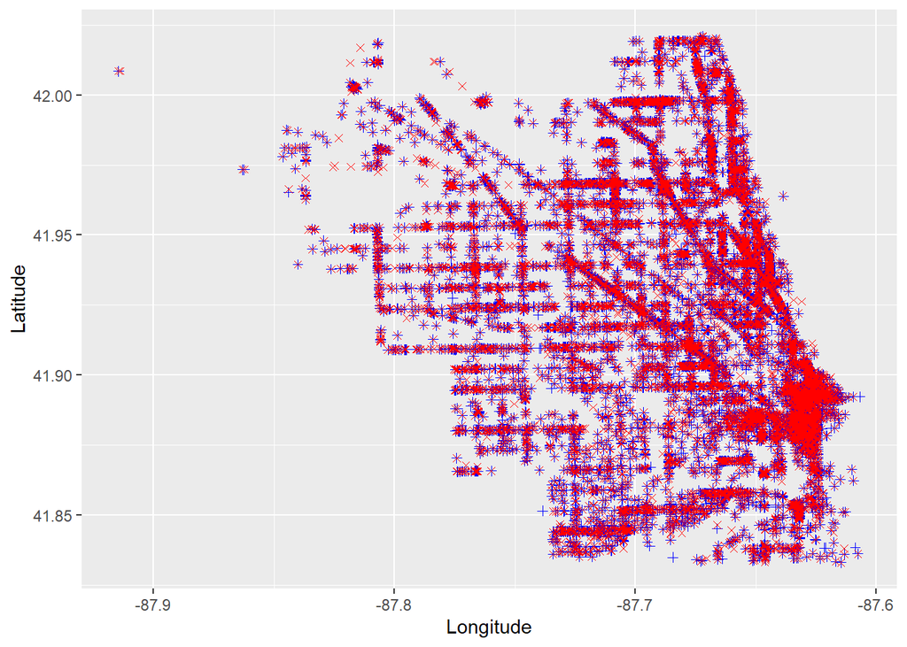

```r
ggplot(data = NorthChicago, mapping = aes(x = Longitude, y = Latitude)) +
  geom_point(data = filter(NorthChicago, violation_severity == 1), color = "blue", pch = 3) +
  geom_point(data = filter(NorthChicago, violation_severity == 0), color = "red", pch = 4)
```

Plot the violation severity for businesses in southern Chicago. The blue + indicates a violation severity of 1 while the red x indicates a violation severity of 0.

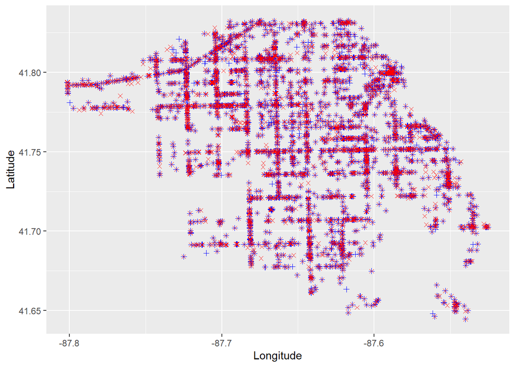

```r
ggplot(data = SouthChicago, mapping = aes(x = Longitude, y = Latitude)) +
  geom_point(data = filter(SouthChicago, violation_severity == 1), color = "blue", pch = 3) +
  geom_point(data = filter(SouthChicago, violation_severity == 0), color = "red", pch = 4)
```

Values for each violation severity type in northern Chicago.

```r
table(NorthChicago$violation_severity)
```

```
##
##     0     1
## 58710 33812
```

Values for each violation severity type in southern Chicago.

```r
table(SouthChicago$violation_severity)
```

```
##
##     0     1
## 20505 11345
```

Finding the proportion of businesses with a violation severity of 1 in northern Chicago and southern Chicago.

```r
NorthChicagoProportion <- ((sum(NorthChicago$violation_severity == 1))/nrow(NorthChicago))*100
NorthChicagoProportion
```

```
## [1] 36.54482
```

```r
SouthChicagoProportion <- ((sum(SouthChicago$violation_severity == 1))/nrow(SouthChicago))*100
SouthChicagoProportion
```

```
## [1] 35.62009
```

**Analysis**

From the plots, we can see that there appears to be more red points than blue points in both northern and southern Chicago, indicating that businesses are more likely to have no severe violations. This is confirmed in the table where we see that northern Chicago has 58,710 businesses with no severe violations and 33,812 with serious violations. Likewise, southern Chicago has 20,505 businesses with no severe violations and 11,345 with serious violations. In northern Chicago, 36.54% of businesses have severe violations while in southern Chicago, this figure is slightly lower, at 35.62%.

**Conclusion**

While the proportions are extremely close and separated by less than a percent, we can conclude that severe violations are more common in Northern Chicago.

**Problem [2]**

Building off the previous question, I thought it would be interesting to see how the western and eastern halves compare. This time, instead of filtering by violation severity, we can filter by the result of the inspection and see if failure rates are higher in the western part of Chicago or in the eastern part of Chicago?

**Plan**

First, dictate the difference between eastern and western Chicago by taking the range of the longitude (max and min) and finding its average. Since the longitude of Chicago is negative, if the longitude is higher than the average, we characterize it as eastern Chicago. Otherwise, it is characterized as western Chicago. Next, create two new data frames for each portion of the city and plot businesses by their pass rate and fail rate. We can combine pass rate and pass with conditions rate in this case since we only want to compare the total pass rate versus the fail rate. Finally, numerically view these results in a table and calculate the proportion of failing inspections for each data frame.

Find the average longitude by taking the average of the min and max longitude.

```r
Longtitude_Min <- min(FoodData$Longitude)
Longtitude_Max <-max(FoodData$Longitude)

Center_Longitude <- (Longtitude_Min + Longtitude_Max)/2

Center_Longitude
```

```
## [1] -87.71976
```

Create two new data frames, one for eastern Chicago and one for western Chicago.

```r
EastChicago <- filter(FoodData, Longitude > Center_Longitude)
WestChicago <- filter(FoodData, Longitude < Center_Longitude)
```

Plot the businesses that passed and failed in eastern Chicago. The orange + indicates that the business passed while the purple x indicates that the business failed.

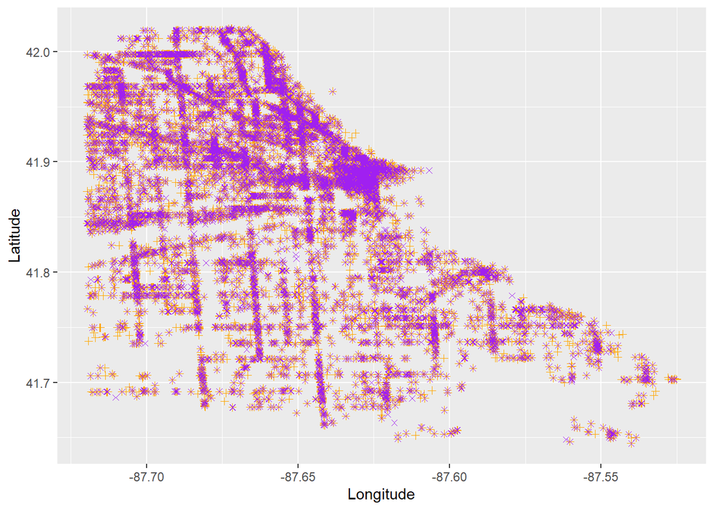

```r
ggplot(data = EastChicago, mapping = aes(x = Longitude, y = Latitude)) +
  geom_point(data = filter(EastChicago, Results == "Pass"), color = "orange", pch = 3) +
  geom_point(data = filter(EastChicago, Results == "Pass w/ conditions"), color = "orange", pch = 3) +
  geom_point(data = filter(EastChicago, Results == "Fail"), color = "purple", pch = 4)
```

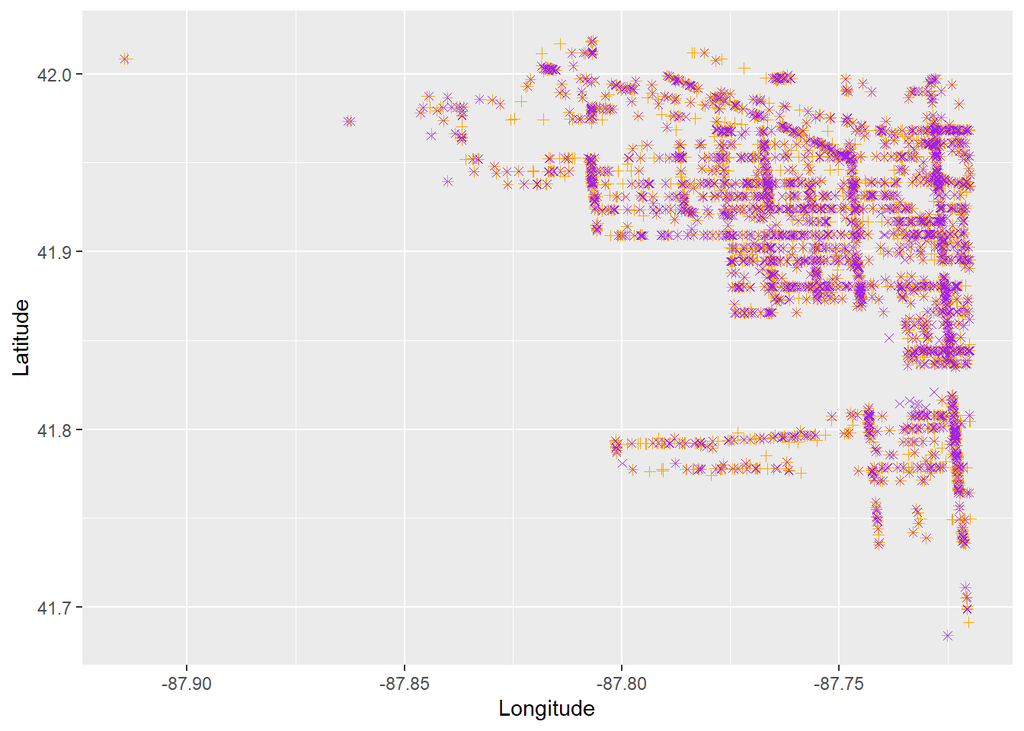

```r
ggplot(data = WestChicago, mapping = aes(x = Longitude, y = Latitude)) +
  geom_point(data = filter(WestChicago, Results == "Pass"), color = "orange", pch = 3) +
  geom_point(data = filter(WestChicago, Results == "Pass w/ conditions"), color = "orange", pch = 3) +
  geom_point(data = filter(WestChicago, Results == "Fail"), color = "purple", pch = 4)
```

Proportions for failing businesses in eastern Chicago.

```r
EastChicagoProportion <- ((sum(EastChicago$Results == "Fail"))/nrow(EastChicago))*100
EastChicagoProportion
```

```
## [1] 24.54595
```

Proportions for failing businesses in western Chicago.

```r
WestChicagoProportion <- ((sum(WestChicago$Results == "Fail"))/nrow(WestChicago))*100
WestChicagoProportion
```

```
## [1] 22.48151
```

**Analysis**

**Conclusion**

Once again, although these numbers are not far off, eastern Chicago has higher fail rates. We can conclude that failure rates are common in the eastern part of Chicago than in the western part of Chicago.

**Problem [3]**

After factoring in regional effects, we can broaden our scope to the entire city and we can see how does the level of risk affect if an establishment passed or failed inspection?

**Plan**

Plot each risk level (Risk 1, Risk 2, Risk 3) in a histogram, filtering individual bars into 3 sections for each of the 3 results (Pass, Fail, Pass with conditions). Afterwards, put this information into a table and find the total proportion of pass, pass with conditions, and fail rates for each of the 3 risk levels.

**Data**